# 04_psm

2022-04-08

## Propensity score matching

## Library

```r
library(dplyr)
library(formr)
```

```r
library(ggplot2)
library(MatchIt)
library(optmatch)
library(cobalt)
```

## Load data

```r
data_main = read.csv(file = "data/data_main.csv")[,-1]
```

## PSM for partner preferences

### Check for missings in covariates to be matched

psm cannot handle missings covariates: language, age, country, gender/sex, relationship status, relationship length

```r
# outcomes = data_main %>% select(interest_hookups,
#                                interest_nonsexrel,
#                                interest_monrel,
#                                interest_monrel,
#                                interest_altrel,
#                                interest_single,
#                                interest_parent,
#                                pref_imp_ks,
#                                pref_imp_att,
#                                pref_imp_fs,
#                                pref_imp_ca,
#                                pref_imp_ei,
#                                pref_imp_sexually_experienced,
#                                self_ks,
#                                self_att,
#                                self_fs,
#                                self_ca,
#                                self_ei,
#                                self_sexually_experienced)

# MatchIt does not allow missing values
data_main_nomiss <- data_main %>% select(language, age, sex, country, relationship_status, relationship_length, sexual_orientation,
                                         pref_imp_ks, pref_imp_att, pref_imp_fs, pref_imp_ca,
                                         pref_imp_ei, pref_imp_sexually_experienced) %>%
                                  na.omit()

table(is.na(data_main_nomiss)) # no more NAs in data set
```

```
##
##  FALSE
## 612768
```

### Check if correct variable type

```r
typeof(data_main_nomiss$sexual_orientation) # is variable of type character, but for PSM it needs to be a factor
```

```
## [1] "character"
```

```r
data_main_nomiss$sexual_orientation = as.factor(data_main_nomiss$sexual_orientation) # convert to factor
levels(data_main_nomiss$sexual_orientation) # check levels of factor
```

```
## [1] "Asexual"               "Straight/Heterosexual"
```

```r
data_main_nomiss$sexual_orientation = factor(data_main_nomiss$sexual_orientation,
                                             levels=rev(levels(data_main_nomiss$sexual_orientation))) # reverse order of factor levels
levels(data_main_nomiss$sexual_orientation) # check factor level order
```

```
## [1] "Straight/Heterosexual" "Asexual"
```

## Matching

### Matching with optimal matching algorithm

```r
om = matchit(sexual_orientation ~ language + age + country + relationship_status + relationship_length, method = "optimal", data = data_main_nomiss) # default setting: propensity score is estimated using logistic regression

om_data = match.data(om) # construct a matched data set from match it object om

nrow(om_data) # 780 observations
```

```
## [1] 780
```

```r
table(om_data$subclass) # data includes only pairs of two observations
```

```
##
##   1   2   3   4   5   6   7   8   9  10  11  12  13  14  15  16  17  18  19  20
##   2   2   2   2   2   2   2   2   2   2   2   2   2   2   2   2   2   2   2   2
##  21  22  23  24  25  26  27  28  29  30  31  32  33  34  35  36  37  38  39  40
##   2   2   2   2   2   2   2   2   2   2   2   2   2   2   2   2   2   2   2   2
##  41  42  43  44  45  46  47  48  49  50  51  52  53  54  55  56  57  58  59  60
##   2   2   2   2   2   2   2   2   2   2   2   2   2   2   2   2   2   2   2   2
##  61  62  63  64  65  66  67  68  69  70  71  72  73  74  75  76  77  78  79  80
##   2   2   2   2   2   2   2   2   2   2   2   2   2   2   2   2   2   2   2   2
##  81  82  83  84  85  86  87  88  89  90  91  92  93  94  95  96  97  98  99 100
##   2   2   2   2   2   2   2   2   2   2   2   2   2   2   2   2   2   2   2   2
## 101 102 103 104 105 106 107 108 109 110 111 112 113 114 115 116 117 118 119 120
##   2   2   2   2   2   2   2   2   2   2   2   2   2   2   2   2   2   2   2   2
## 121 122 123 124 125 126 127 128 129 130 131 132 133 134 135 136 137 138 139 140
##   2   2   2   2   2   2   2   2   2   2   2   2   2   2   2   2   2   2   2   2
```

[output cut: 26 more lines]

```r
dim(om_data) # 780 observations and 16 variables
```

```
## [1] 780  16
```

#### Check balance

```r
summary_om = summary(om, standardize = T)
print(summary_om)
```

```
##
## Call:
## matchit(formula = sexual_orientation ~ language + age + country +
##     relationship_status + relationship_length, data = data_main_nomiss,
##     method = "optimal")
##
## Summary of Balance for All Data:
##                                         Means Treated Means Control
## distance                                       0.0302        0.0081
## languagechinese                                0.0000        0.0058
## languagedanish                                 0.0154        0.0285
## languageenglish                                0.4974        0.2273
## languagefrench                                 0.0641        0.1953
## languagegerman                                 0.1538        0.1392
## languageitalian                                0.0385        0.0629
## languagejapanese                               0.0308        0.0240
## languageportuguese                             0.0487        0.0727
## languagerussian                                0.0179        0.0164
## languagespanish                                0.1333        0.2279
## age                                           23.9410       25.1973
## countryAfghanistan                             0.0000        0.0001
## countryAlbania                                 0.0000        0.0001
## countryAlgeria                                 0.0026        0.0003
## countryAndorra                                 0.0000        0.0004
## countryAngola                                  0.0000        0.0000
## countryAntigua and Barbuda                     0.0000        0.0001
## countryArgentina                               0.0231        0.0172
## countryArmenia                                 0.0000        0.0001
## countryAruba                                   0.0000        0.0000
## countryAustralia                               0.0333        0.0108
## countryAustria                                 0.0128        0.0127
## countryAzerbaijan                              0.0000        0.0000
## countryBahamas, The                            0.0000        0.0001
## countryBahrain                                 0.0000        0.0001
## countryBangladesh                              0.0000        0.0000
## countryBarbados                                0.0000        0.0001
## countryBelarus                                 0.0000        0.0010
## countryBelgium                                 0.0000        0.0091
## countryBelize                                  0.0000        0.0001
## countryBenin                                   0.0000        0.0001
```

[output cut: 1460 more lines]

```
## countryUzbekistan                            100.0
## countryVenezuela                             100.0
## countryVietnam                               100.0
## countryZimbabwe                              100.0
## relationship_statusLong-term                  89.7
## relationship_statusNo relationship            90.5
## relationship_statusShort-term                 93.9
## relationship_length                           85.0
##
## Sample Sizes:
##           Control Treated
## All         46746     390
## Matched       390     390
## Unmatched   46356       0
## Discarded       0       0
```

```r
bal.tab(om, m.threshold = 0.1, un = T) #smd
```

```
## Call
##  matchit(formula = sexual_orientation ~ language + age + country +
##     relationship_status + relationship_length, data = data_main_nomiss,
##     method = "optimal")
##
## Balance Measures
##                                              Type Diff.Un Diff.Adj
## distance                                 Distance  0.7498   0.0008
## language_chinese                           Binary -0.0058   0.0000
## language_danish                            Binary -0.0131   0.0154
## language_english                           Binary  0.2701   0.1949
## language_french                            Binary -0.1312   0.0615
## language_german                            Binary  0.0146  -0.3641
## language_italian                           Binary -0.0245   0.0385
## language_japanese                          Binary  0.0068   0.0308
## language_portuguese                        Binary -0.0240   0.0487
## language_russian                           Binary  0.0015   0.0154
## language_spanish                           Binary -0.0946  -0.0410
## age                                       Contin. -0.1964  -0.3467
## country_Afghanistan                        Binary -0.0001   0.0000
## country_Albania                            Binary -0.0001   0.0000
## country_Algeria                            Binary  0.0022   0.0000
## country_Andorra                            Binary -0.0004   0.0000
## country_Angola                             Binary -0.0000   0.0000
## country_Antigua and Barbuda                Binary -0.0001   0.0000
## country_Argentina                          Binary  0.0059   0.0179
## country_Armenia                            Binary -0.0001   0.0000
## country_Aruba                              Binary -0.0000   0.0000
## country_Australia                          Binary  0.0226  -0.0282
## country_Austria                            Binary  0.0002  -0.0385
## country_Azerbaijan                         Binary -0.0000   0.0000
## country_Bahamas, The                       Binary -0.0001   0.0000
## country_Bahrain                            Binary -0.0001   0.0000
## country_Bangladesh                         Binary -0.0000   0.0000
## country_Barbados                           Binary -0.0001   0.0000
## country_Belarus                            Binary -0.0010   0.0000
## country_Belgium                            Binary -0.0091   0.0000
## country_Belize                             Binary -0.0001   0.0000
## country_Benin                              Binary -0.0001   0.0000
## country_Bhutan                             Binary -0.0000   0.0000
```

[output cut: 340 more lines]

```
##
## Balance tally for mean differences
##                    count
## Balanced, <0.1       181
## Not Balanced, >0.1     5
##
## Variable with the greatest mean difference
##         Variable Diff.Adj        M.Threshold
##  language_german  -0.3641 Not Balanced, >0.1
##
## Sample sizes
##           Control Treated
## All         46746     390
## Matched       390     390
## Unmatched   46356       0
```

```r
bal.tab(om, v.threshold = 2, un = T) #vr (can only be calculated for continuous variables)
```

```
## Call
##  matchit(formula = sexual_orientation ~ language + age + country +
##     relationship_status + relationship_length, data = data_main_nomiss,
##     method = "optimal")
##
## Balance Measures
##                                              Type Diff.Un V.Ratio.Un Diff.Adj
## distance                                 Distance  0.7498     4.8204   0.0008
## language_chinese                           Binary -0.0058          .   0.0000
## language_danish                            Binary -0.0131          .   0.0154
## language_english                           Binary  0.2701          .   0.1949
## language_french                            Binary -0.1312          .   0.0615
## language_german                            Binary  0.0146          .  -0.3641
## language_italian                           Binary -0.0245          .   0.0385
## language_japanese                          Binary  0.0068          .   0.0308
## language_portuguese                        Binary -0.0240          .   0.0487
## language_russian                           Binary  0.0015          .   0.0154
## language_spanish                           Binary -0.0946          .  -0.0410
## age                                       Contin. -0.1964     0.7691  -0.3467
## country_Afghanistan                        Binary -0.0001          .   0.0000
## country_Albania                            Binary -0.0001          .   0.0000
## country_Algeria                            Binary  0.0022          .   0.0000
## country_Andorra                            Binary -0.0004          .   0.0000
## country_Angola                             Binary -0.0000          .   0.0000
## country_Antigua and Barbuda                Binary -0.0001          .   0.0000
## country_Argentina                          Binary  0.0059          .   0.0179
## country_Armenia                            Binary -0.0001          .   0.0000
## country_Aruba                              Binary -0.0000          .   0.0000
## country_Australia                          Binary  0.0226          .  -0.0282
## country_Austria                            Binary  0.0002          .  -0.0385
## country_Azerbaijan                         Binary -0.0000          .   0.0000
## country_Bahamas, The                       Binary -0.0001          .   0.0000
## country_Bahrain                            Binary -0.0001          .   0.0000
## country_Bangladesh                         Binary -0.0000          .   0.0000
## country_Barbados                           Binary -0.0001          .   0.0000
## country_Belarus                            Binary -0.0010          .   0.0000
## country_Belgium                            Binary -0.0091          .   0.0000
## country_Belize                             Binary -0.0001          .   0.0000
## country_Benin                              Binary -0.0001          .   0.0000
## country_Bhutan                             Binary -0.0000          .   0.0000
```

[output cut: 340 more lines]

```
##
## Balance tally for variance ratios
##                  count
## Balanced, <2         3
## Not Balanced, >2     0
##
## Variable with the greatest variance ratio
##  Variable V.Ratio.Adj  V.Threshold
##       age      0.5395 Balanced, <2
##
## Sample sizes
##           Control Treated
## All         46746     390
## Matched       390     390
## Unmatched   46356       0
```

#### Visualize

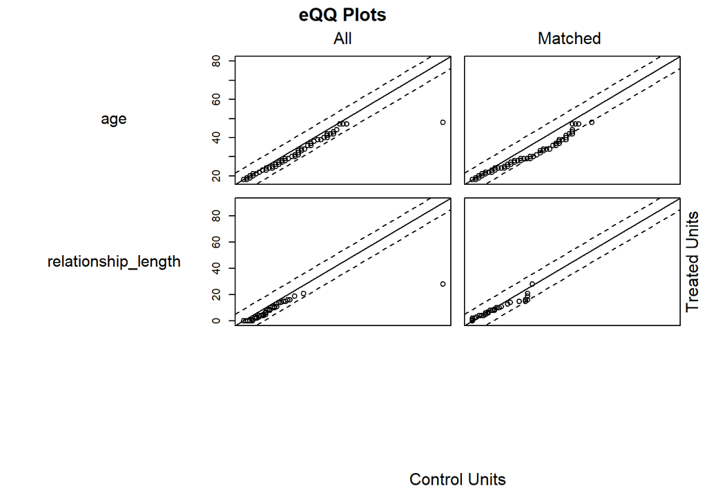

```r
# Q-Q plot
plot(om, type = "qq", interactive = FALSE, which.xs = c("age", "relationship_length"))
```

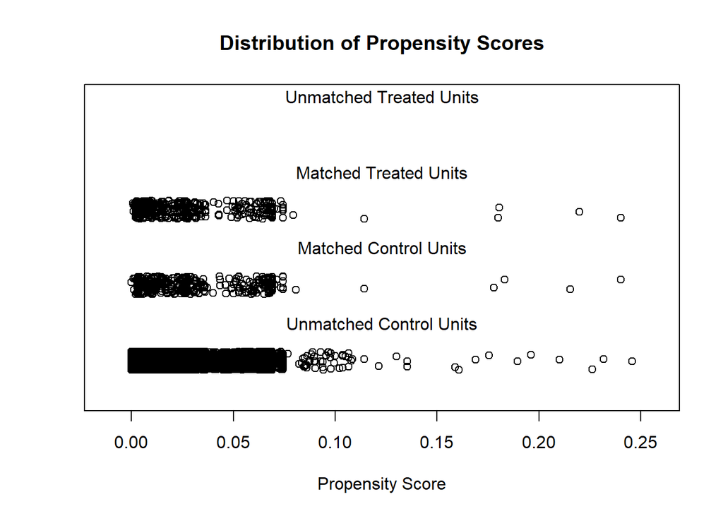

```r
# looks worse than before matching

# Jitter plot
plot(om, type = "jitter", interactive = FALSE)
```

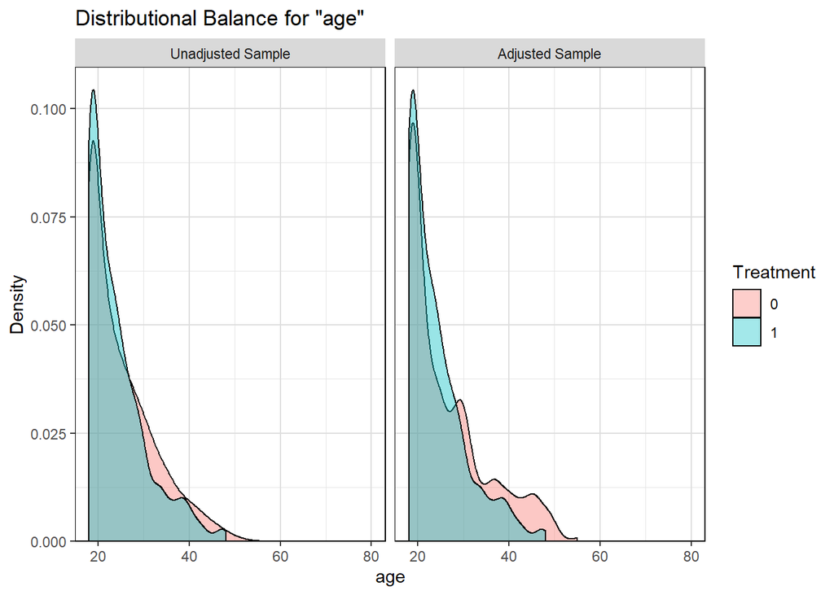

```r
# with cobalt package:
# distributional density/histogram
bal.plot(om, var.name = "age", which = "both", grid = T)
```

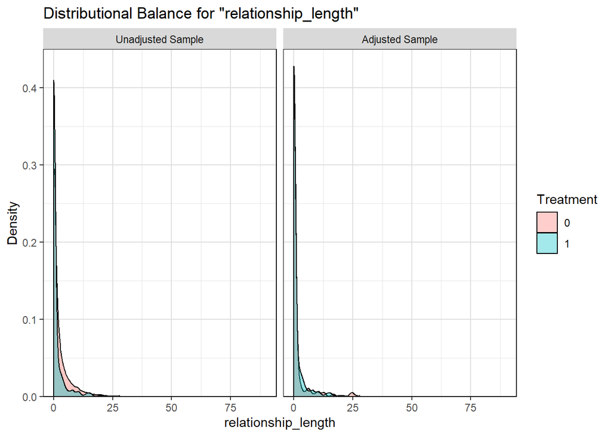

```r
bal.plot(om, var.name = "relationship_length", which = "both", grid = T)
```

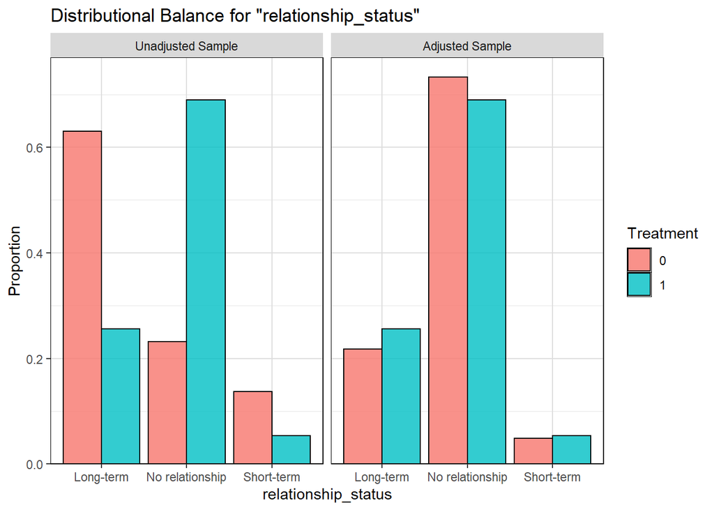

```r
bal.plot(om, var.name = "relationship_status", which = "both", grid = T)
```

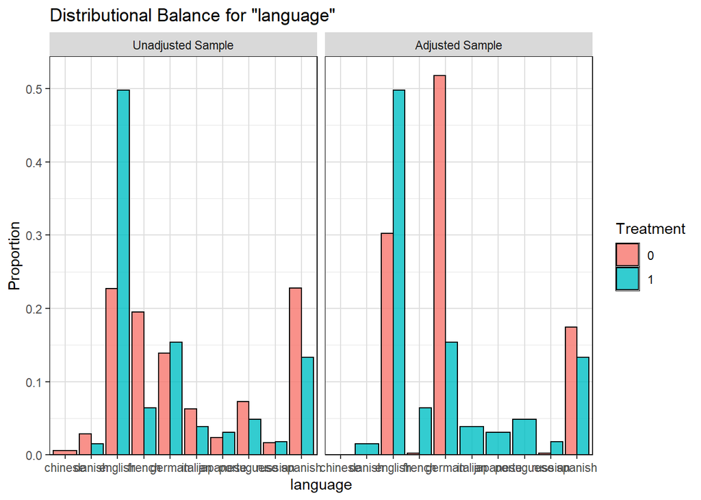

```r
bal.plot(om, var.name = "language", which = "both", grid = T) # looks worse than before matching, some countries are not represented for heterosexual individuals anymore
```

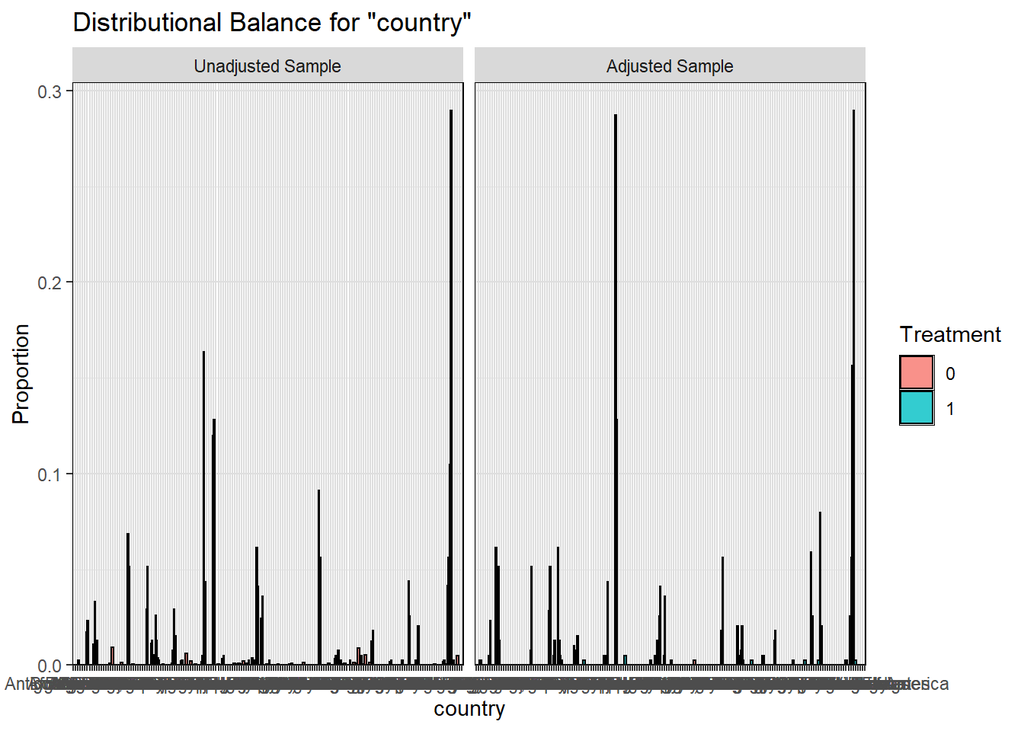

```r
bal.plot(om, var.name = "country", which = "both", grid = T) # recht unübersichtlich
```

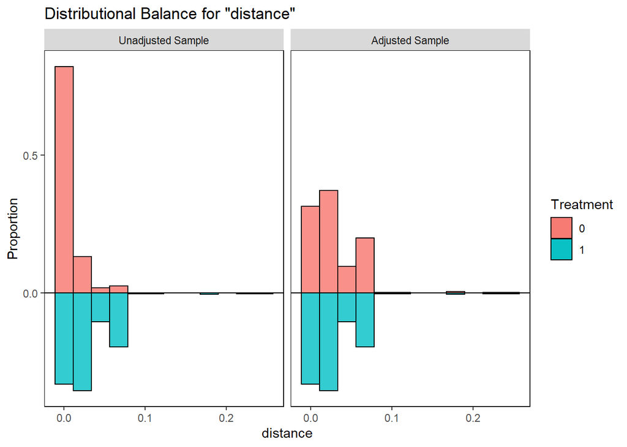

```r
bal.plot(om, var.name = "distance", which = "both",
         type = "histogram", mirror = TRUE) # for propensity score
```

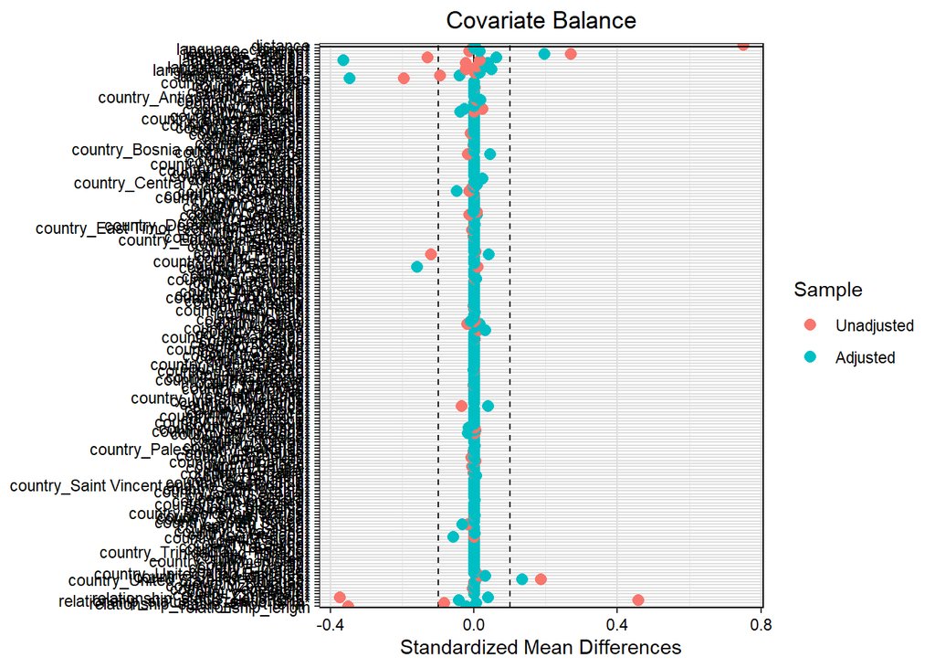

```r
love.plot(bal.tab(om, m.threshold = 0.1),
          stat = "mean.diffs",
          grid = T,
          stars = "raw",
          abs = F)
```

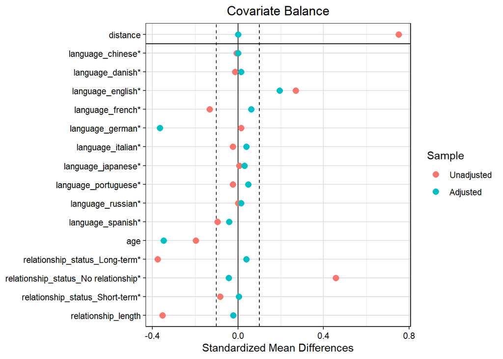

```r
# mega unübersichtlich wegen Country Variable

# remove country variable for love plot
om_without_country = om
om_without_country$X[c("country")] <- NULL

love.plot(bal.tab(om_without_country, m.threshold = 0.1),
          stat = "mean.diffs",
          grid = T,
          stars = "raw",
          abs = F)
```

```r
# In cobalt, you can use the formula method as follows:
#
# cobalt::love.plot(y ~ x1 + x2, data = D, weights = get.w(m.out))
# Because you control which covariates are used, you don't have to display the covariates you don't want.
#
# In MatchIt, one hacky way to do this would be to manually remove those variables from the matchit object. That is, you could run
#
# m.out$X[c("location")] <- NULL
# before running summary() and the location variable will be removed from the output.
```

Optimal matching results in five covariates not being balanced after matching (based on SMDs).

### Matching with nearest-neighbor-algortihm without caliper

```r
nnm <- matchit(sexual_orientation ~ language + age + country + relationship_status + relationship_length, method = "nearest", data = data_main_nomiss)

nnm_data <- match.data(nnm)

nrow(nnm_data) # 780 observations
```

```
## [1] 780
```

```r
table(nnm_data$subclass) # data includes only pairs of two observations
```

```
##
##   1   2   3   4   5   6   7   8   9  10  11  12  13  14  15  16  17  18  19  20
##   2   2   2   2   2   2   2   2   2   2   2   2   2   2   2   2   2   2   2   2
##  21  22  23  24  25  26  27  28  29  30  31  32  33  34  35  36  37  38  39  40
##   2   2   2   2   2   2   2   2   2   2   2   2   2   2   2   2   2   2   2   2
##  41  42  43  44  45  46  47  48  49  50  51  52  53  54  55  56  57  58  59  60
##   2   2   2   2   2   2   2   2   2   2   2   2   2   2   2   2   2   2   2   2
##  61  62  63  64  65  66  67  68  69  70  71  72  73  74  75  76  77  78  79  80
##   2   2   2   2   2   2   2   2   2   2   2   2   2   2   2   2   2   2   2   2
##  81  82  83  84  85  86  87  88  89  90  91  92  93  94  95  96  97  98  99 100
##   2   2   2   2   2   2   2   2   2   2   2   2   2   2   2   2   2   2   2   2
## 101 102 103 104 105 106 107 108 109 110 111 112 113 114 115 116 117 118 119 120
##   2   2   2   2   2   2   2   2   2   2   2   2   2   2   2   2   2   2   2   2
## 121 122 123 124 125 126 127 128 129 130 131 132 133 134 135 136 137 138 139 140
##   2   2   2   2   2   2   2   2   2   2   2   2   2   2   2   2   2   2   2   2
```

[output cut: 26 more lines]

```r
dim(nnm_data) # 780 observations and 16 variables
```

```
## [1] 780  16
```

No asexual unmatched.

#### Check balance

```r
summary_nnm = summary(nnm, standardize = T)
print(summary_nnm)
```

```
##
## Call:
## matchit(formula = sexual_orientation ~ language + age + country +
##     relationship_status + relationship_length, data = data_main_nomiss,
##     method = "nearest")
##
## Summary of Balance for All Data:
##                                         Means Treated Means Control
## distance                                       0.0302        0.0081
## languagechinese                                0.0000        0.0058
## languagedanish                                 0.0154        0.0285
## languageenglish                                0.4974        0.2273
## languagefrench                                 0.0641        0.1953
## languagegerman                                 0.1538        0.1392
## languageitalian                                0.0385        0.0629
## languagejapanese                               0.0308        0.0240
## languageportuguese                             0.0487        0.0727
## languagerussian                                0.0179        0.0164
## languagespanish                                0.1333        0.2279
## age                                           23.9410       25.1973
## countryAfghanistan                             0.0000        0.0001
## countryAlbania                                 0.0000        0.0001
## countryAlgeria                                 0.0026        0.0003
## countryAndorra                                 0.0000        0.0004
## countryAngola                                  0.0000        0.0000
## countryAntigua and Barbuda                     0.0000        0.0001
## countryArgentina                               0.0231        0.0172
## countryArmenia                                 0.0000        0.0001
## countryAruba                                   0.0000        0.0000
## countryAustralia                               0.0333        0.0108
## countryAustria                                 0.0128        0.0127
## countryAzerbaijan                              0.0000        0.0000
## countryBahamas, The                            0.0000        0.0001
## countryBahrain                                 0.0000        0.0001
## countryBangladesh                              0.0000        0.0000
## countryBarbados                                0.0000        0.0001
## countryBelarus                                 0.0000        0.0010
## countryBelgium                                 0.0000        0.0091
## countryBelize                                  0.0000        0.0001
## countryBenin                                   0.0000        0.0001
```

[output cut: 1460 more lines]

```
## countryUzbekistan                           100.0
## countryVenezuela                            100.0
## countryVietnam                              100.0
## countryZimbabwe                             100.0
## relationship_statusLong-term                 97.3
## relationship_statusNo relationship           98.3
## relationship_statusShort-term                96.9
## relationship_length                          97.2
##
## Sample Sizes:
##           Control Treated
## All         46746     390
## Matched       390     390
## Unmatched   46356       0
## Discarded       0       0
```

```r
bal.tab(nnm, m.threshold = 0.1, un = T) #smd
```

```
## Call
##  matchit(formula = sexual_orientation ~ language + age + country +
##     relationship_status + relationship_length, data = data_main_nomiss,
##     method = "nearest")
##
## Balance Measures
##                                              Type Diff.Un Diff.Adj
## distance                                 Distance  0.7498   0.0003
## language_chinese                           Binary -0.0058   0.0000
## language_danish                            Binary -0.0131   0.0000
## language_english                           Binary  0.2701   0.0051
## language_french                            Binary -0.1312  -0.0026
## language_german                            Binary  0.0146   0.0000
## language_italian                           Binary -0.0245  -0.0026
## language_japanese                          Binary  0.0068   0.0000
## language_portuguese                        Binary -0.0240   0.0000
## language_russian                           Binary  0.0015   0.0000
## language_spanish                           Binary -0.0946   0.0000
## age                                       Contin. -0.1964  -0.0277
## country_Afghanistan                        Binary -0.0001   0.0000
## country_Albania                            Binary -0.0001   0.0000
## country_Algeria                            Binary  0.0022   0.0026
## country_Andorra                            Binary -0.0004   0.0000
## country_Angola                             Binary -0.0000   0.0000
## country_Antigua and Barbuda                Binary -0.0001   0.0000
## country_Argentina                          Binary  0.0059   0.0000
## country_Armenia                            Binary -0.0001   0.0000
## country_Aruba                              Binary -0.0000   0.0000
## country_Australia                          Binary  0.0226   0.0000
## country_Austria                            Binary  0.0002  -0.0026
## country_Azerbaijan                         Binary -0.0000   0.0000
## country_Bahamas, The                       Binary -0.0001   0.0000
## country_Bahrain                            Binary -0.0001   0.0000
## country_Bangladesh                         Binary -0.0000   0.0000
## country_Barbados                           Binary -0.0001   0.0000
## country_Belarus                            Binary -0.0010   0.0000
## country_Belgium                            Binary -0.0091   0.0000
## country_Belize                             Binary -0.0001   0.0000
## country_Benin                              Binary -0.0001   0.0000
## country_Bhutan                             Binary -0.0000   0.0000
```

[output cut: 340 more lines]

```
##
## Balance tally for mean differences
##                    count
## Balanced, <0.1       186
## Not Balanced, >0.1     0
##
## Variable with the greatest mean difference
##  Variable Diff.Adj    M.Threshold
##       age  -0.0277 Balanced, <0.1
##
## Sample sizes
##           Control Treated
## All         46746     390
## Matched       390     390
## Unmatched   46356       0
```

```r
bal.tab(nnm, v.threshold = 2, un = T) #vr (can only be calculated for continuous variables)
```

```
## Call
##  matchit(formula = sexual_orientation ~ language + age + country +
##     relationship_status + relationship_length, data = data_main_nomiss,
##     method = "nearest")
##
## Balance Measures
##                                              Type Diff.Un V.Ratio.Un Diff.Adj
## distance                                 Distance  0.7498     4.8204   0.0003
## language_chinese                           Binary -0.0058          .   0.0000
## language_danish                            Binary -0.0131          .   0.0000
## language_english                           Binary  0.2701          .   0.0051
## language_french                            Binary -0.1312          .  -0.0026
## language_german                            Binary  0.0146          .   0.0000
## language_italian                           Binary -0.0245          .  -0.0026
## language_japanese                          Binary  0.0068          .   0.0000
## language_portuguese                        Binary -0.0240          .   0.0000
## language_russian                           Binary  0.0015          .   0.0000
## language_spanish                           Binary -0.0946          .   0.0000
## age                                       Contin. -0.1964     0.7691  -0.0277
## country_Afghanistan                        Binary -0.0001          .   0.0000
## country_Albania                            Binary -0.0001          .   0.0000
## country_Algeria                            Binary  0.0022          .   0.0026
## country_Andorra                            Binary -0.0004          .   0.0000
## country_Angola                             Binary -0.0000          .   0.0000
## country_Antigua and Barbuda                Binary -0.0001          .   0.0000
## country_Argentina                          Binary  0.0059          .   0.0000
## country_Armenia                            Binary -0.0001          .   0.0000
## country_Aruba                              Binary -0.0000          .   0.0000
## country_Australia                          Binary  0.0226          .   0.0000
## country_Austria                            Binary  0.0002          .  -0.0026
## country_Azerbaijan                         Binary -0.0000          .   0.0000
## country_Bahamas, The                       Binary -0.0001          .   0.0000
## country_Bahrain                            Binary -0.0001          .   0.0000
## country_Bangladesh                         Binary -0.0000          .   0.0000
## country_Barbados                           Binary -0.0001          .   0.0000
## country_Belarus                            Binary -0.0010          .   0.0000
## country_Belgium                            Binary -0.0091          .   0.0000
## country_Belize                             Binary -0.0001          .   0.0000
## country_Benin                              Binary -0.0001          .   0.0000
## country_Bhutan                             Binary -0.0000          .   0.0000
```

[output cut: 340 more lines]

```
##
## Balance tally for variance ratios
##                  count
## Balanced, <2         3
## Not Balanced, >2     0
##
## Variable with the greatest variance ratio
##  Variable V.Ratio.Adj  V.Threshold
##       age      0.9376 Balanced, <2
##
## Sample sizes
##           Control Treated
## All         46746     390
## Matched       390     390
## Unmatched   46356       0
```

All variables balanced.

#### Visualize

```r
# Q-Q plot
plot(nnm, type = "qq", interactive = FALSE, which.xs = c("age", "relationship_length"))
```

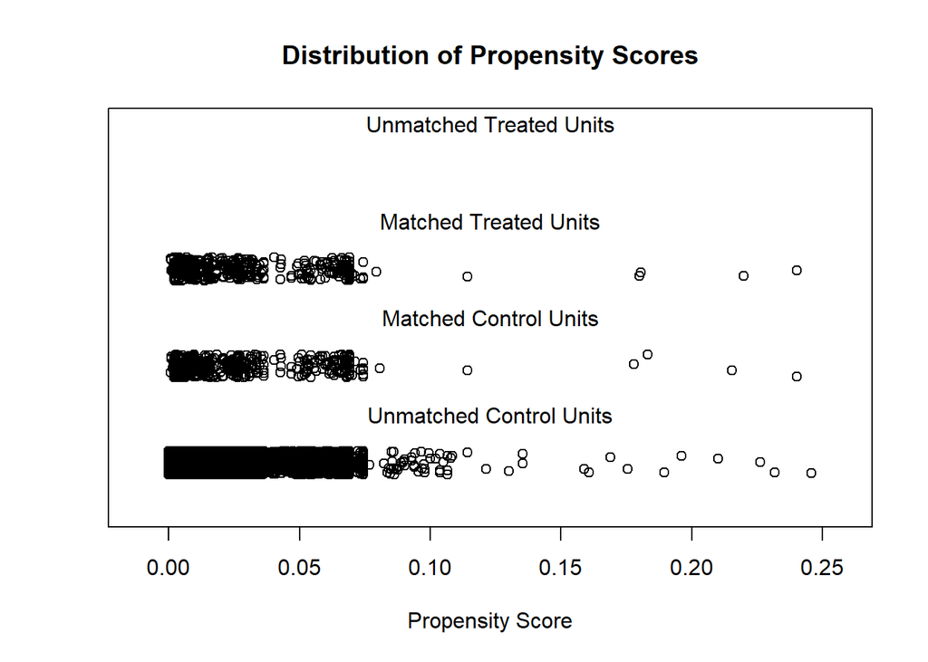

```r
# looks better after matching

# Jitter plot
plot(nnm, type = "jitter", interactive = FALSE)
```

```r
# with cobalt package:
# distributional density/histogram
bal.plot(nnm, var.name = "age", which = "both", grid = T)
```

```r
bal.plot(nnm, var.name = "relationship_length", which = "both", grid = T)
```

```r
bal.plot(nnm, var.name = "relationship_status", which = "both", grid = T)
```

```r
bal.plot(nnm, var.name = "language", which = "both", grid = T)
```

```r
bal.plot(nnm, var.name = "country", which = "both", grid = T) # recht unübersichtlich
```

```r
love.plot(bal.tab(nnm, m.threshold = 0.1),
          stat = "mean.diffs",
          grid = T,
          stars = "raw",
          abs = F)
```

```r
# mega unübersichtlich wegen Country Variable

# remove country variable for love plot
nnm_without_country = nnm
nnm_without_country$X[c("country")] <- NULL

love.plot(bal.tab(nnm_without_country, m.threshold = 0.1),
          stat = "mean.diffs",
          grid = T,
          stars = "raw",
          abs = F)
```

```r
nnm_25 <- matchit(sexual_orientation ~ language + age + country + relationship_status + relationship_length, method = "nearest", caliper = 0.25, data = data_main_nomiss)

nnm_25_data <- match.data(nnm_25)

nrow(nnm_25_data) # 778 observations
```

```
## [1] 778
```

```r
table(nnm_25_data$subclass) # data includes only pairs of two observations
```

```
##
##   1   2   3   4   5   6   7   8   9  10  11  12  13  14  15  16  17  18  19  20
##   2   2   2   2   2   2   2   2   2   2   2   2   2   2   2   2   2   2   2   2
##  21  22  23  24  25  26  27  28  29  30  31  32  33  34  35  36  37  38  39  40
##   2   2   2   2   2   2   2   2   2   2   2   2   2   2   2   2   2   2   2   2
##  41  42  43  44  45  46  47  48  49  50  51  52  53  54  55  56  57  58  59  60
##   2   2   2   2   2   2   2   2   2   2   2   2   2   2   2   2   2   2   2   2
##  61  62  63  64  65  66  67  68  69  70  71  72  73  74  75  76  77  78  79  80
##   2   2   2   2   2   2   2   2   2   2   2   2   2   2   2   2   2   2   2   2
##  81  82  83  84  85  86  87  88  89  90  91  92  93  94  95  96  97  98  99 100
##   2   2   2   2   2   2   2   2   2   2   2   2   2   2   2   2   2   2   2   2
## 101 102 103 104 105 106 107 108 109 110 111 112 113 114 115 116 117 118 119 120
##   2   2   2   2   2   2   2   2   2   2   2   2   2   2   2   2   2   2   2   2
## 121 122 123 124 125 126 127 128 129 130 131 132 133 134 135 136 137 138 139 140
##   2   2   2   2   2   2   2   2   2   2   2   2   2   2   2   2   2   2   2   2
```

[output cut: 26 more lines]

```r
dim(nnm_25_data) # 778 observations and 16 variables
```

```
## [1] 778  16
```

1 asexual unmatched.

#### Check balance

```r
summary_nnm_25 = summary(nnm_25, standardize = T)
print(summary_nnm_25)
```

```
##
## Call:
## matchit(formula = sexual_orientation ~ language + age + country +
##     relationship_status + relationship_length, data = data_main_nomiss,
##     method = "nearest", caliper = 0.25)
##
## Summary of Balance for All Data:
##                                         Means Treated Means Control
## distance                                       0.0302        0.0081
## languagechinese                                0.0000        0.0058
## languagedanish                                 0.0154        0.0285
## languageenglish                                0.4974        0.2273
## languagefrench                                 0.0641        0.1953
## languagegerman                                 0.1538        0.1392
## languageitalian                                0.0385        0.0629
## languagejapanese                               0.0308        0.0240
## languageportuguese                             0.0487        0.0727
## languagerussian                                0.0179        0.0164
## languagespanish                                0.1333        0.2279
## age                                           23.9410       25.1973
## countryAfghanistan                             0.0000        0.0001
## countryAlbania                                 0.0000        0.0001
## countryAlgeria                                 0.0026        0.0003
## countryAndorra                                 0.0000        0.0004
## countryAngola                                  0.0000        0.0000
## countryAntigua and Barbuda                     0.0000        0.0001
## countryArgentina                               0.0231        0.0172
## countryArmenia                                 0.0000        0.0001
## countryAruba                                   0.0000        0.0000
## countryAustralia                               0.0333        0.0108
## countryAustria                                 0.0128        0.0127
## countryAzerbaijan                              0.0000        0.0000
## countryBahamas, The                            0.0000        0.0001
## countryBahrain                                 0.0000        0.0001
## countryBangladesh                              0.0000        0.0000
## countryBarbados                                0.0000        0.0001
## countryBelarus                                 0.0000        0.0010
## countryBelgium                                 0.0000        0.0091
## countryBelize                                  0.0000        0.0001
## countryBenin                                   0.0000        0.0001
```

[output cut: 1460 more lines]

```
## countryUzbekistan                           100.0
## countryVenezuela                            100.0
## countryVietnam                              100.0
## countryZimbabwe                             100.0
## relationship_statusLong-term                 97.3
## relationship_statusNo relationship           98.3
## relationship_statusShort-term                96.9
## relationship_length                          97.2
##
## Sample Sizes:
##           Control Treated
## All         46746     390
## Matched       389     389
## Unmatched   46357       1
## Discarded       0       0
```

```r
bal.tab(nnm_25, m.threshold = 0.1, un = T) #smd
```

```
## Call
##  matchit(formula = sexual_orientation ~ language + age + country +
##     relationship_status + relationship_length, data = data_main_nomiss,
##     method = "nearest", caliper = 0.25)
##
## Balance Measures
##                                              Type Diff.Un Diff.Adj
## distance                                 Distance  0.7498  -0.0001
## language_chinese                           Binary -0.0058   0.0000
## language_danish                            Binary -0.0131   0.0000
## language_english                           Binary  0.2701   0.0051
## language_french                            Binary -0.1312  -0.0026
## language_german                            Binary  0.0146   0.0000
## language_italian                           Binary -0.0245  -0.0026
## language_japanese                          Binary  0.0068   0.0000
## language_portuguese                        Binary -0.0240   0.0000
## language_russian                           Binary  0.0015   0.0000
## language_spanish                           Binary -0.0946   0.0000
## age                                       Contin. -0.1964  -0.0257
## country_Afghanistan                        Binary -0.0001   0.0000
## country_Albania                            Binary -0.0001   0.0000
## country_Algeria                            Binary  0.0022   0.0000
## country_Andorra                            Binary -0.0004   0.0000
## country_Angola                             Binary -0.0000   0.0000
## country_Antigua and Barbuda                Binary -0.0001   0.0000
## country_Argentina                          Binary  0.0059   0.0000
## country_Armenia                            Binary -0.0001   0.0000
## country_Aruba                              Binary -0.0000   0.0000
## country_Australia                          Binary  0.0226   0.0000
## country_Austria                            Binary  0.0002  -0.0026
## country_Azerbaijan                         Binary -0.0000   0.0000
## country_Bahamas, The                       Binary -0.0001   0.0000
## country_Bahrain                            Binary -0.0001   0.0000
## country_Bangladesh                         Binary -0.0000   0.0000
## country_Barbados                           Binary -0.0001   0.0000
## country_Belarus                            Binary -0.0010   0.0000
## country_Belgium                            Binary -0.0091   0.0000
## country_Belize                             Binary -0.0001   0.0000
## country_Benin                              Binary -0.0001   0.0000
## country_Bhutan                             Binary -0.0000   0.0000
```

[output cut: 340 more lines]

```
##
## Balance tally for mean differences
##                    count
## Balanced, <0.1       186
## Not Balanced, >0.1     0
##
## Variable with the greatest mean difference
##  Variable Diff.Adj    M.Threshold
##       age  -0.0257 Balanced, <0.1
##
## Sample sizes
##           Control Treated
## All         46746     390
## Matched       389     389
## Unmatched   46357       1
```

```r
bal.tab(nnm_25, v.threshold = 2, un = T) #vr (can only be calculated for continuous variables)
```

```
## Call
##  matchit(formula = sexual_orientation ~ language + age + country +
##     relationship_status + relationship_length, data = data_main_nomiss,
##     method = "nearest", caliper = 0.25)
##
## Balance Measures
##                                              Type Diff.Un V.Ratio.Un Diff.Adj
## distance                                 Distance  0.7498     4.8204  -0.0001
## language_chinese                           Binary -0.0058          .   0.0000
## language_danish                            Binary -0.0131          .   0.0000
## language_english                           Binary  0.2701          .   0.0051
## language_french                            Binary -0.1312          .  -0.0026
## language_german                            Binary  0.0146          .   0.0000
## language_italian                           Binary -0.0245          .  -0.0026
## language_japanese                          Binary  0.0068          .   0.0000
## language_portuguese                        Binary -0.0240          .   0.0000
## language_russian                           Binary  0.0015          .   0.0000
## language_spanish                           Binary -0.0946          .   0.0000
## age                                       Contin. -0.1964     0.7691  -0.0257
## country_Afghanistan                        Binary -0.0001          .   0.0000
## country_Albania                            Binary -0.0001          .   0.0000
## country_Algeria                            Binary  0.0022          .   0.0000
## country_Andorra                            Binary -0.0004          .   0.0000
## country_Angola                             Binary -0.0000          .   0.0000
## country_Antigua and Barbuda                Binary -0.0001          .   0.0000
## country_Argentina                          Binary  0.0059          .   0.0000
## country_Armenia                            Binary -0.0001          .   0.0000
## country_Aruba                              Binary -0.0000          .   0.0000
## country_Australia                          Binary  0.0226          .   0.0000
## country_Austria                            Binary  0.0002          .  -0.0026
## country_Azerbaijan                         Binary -0.0000          .   0.0000
## country_Bahamas, The                       Binary -0.0001          .   0.0000
## country_Bahrain                            Binary -0.0001          .   0.0000
## country_Bangladesh                         Binary -0.0000          .   0.0000
## country_Barbados                           Binary -0.0001          .   0.0000
## country_Belarus                            Binary -0.0010          .   0.0000
## country_Belgium                            Binary -0.0091          .   0.0000
## country_Belize                             Binary -0.0001          .   0.0000
## country_Benin                              Binary -0.0001          .   0.0000
## country_Bhutan                             Binary -0.0000          .   0.0000
```

[output cut: 340 more lines]

```
##
## Balance tally for variance ratios
##                  count
## Balanced, <2         3
## Not Balanced, >2     0
##
## Variable with the greatest variance ratio
##  Variable V.Ratio.Adj  V.Threshold
##       age      0.9389 Balanced, <2
##
## Sample sizes
##           Control Treated
## All         46746     390
## Matched       389     389
## Unmatched   46357       1
```

All variables are balanced.

#### Visualize

```r
# Q-Q plot
plot(nnm_25, type = "qq", interactive = FALSE, which.xs = c("age", "relationship_length"))
```

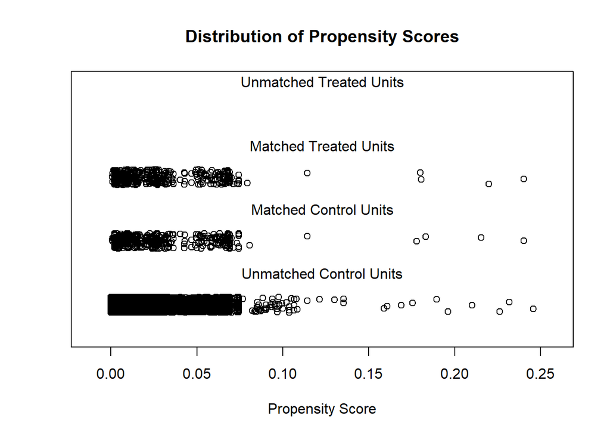

```r
# sieht besser aus als vorher

# Jitter plot
plot(nnm, type = "jitter", interactive = FALSE)
```

```r
# with cobalt package:
# distributional density/histogram
bal.plot(nnm, var.name = "age", which = "both", grid = T)
```

```r
bal.plot(nnm, var.name = "relationship_length", which = "both", grid = T)
```

```r
bal.plot(nnm, var.name = "relationship_status", which = "both", grid = T)
```

```r
bal.plot(nnm, var.name = "language", which = "both", grid = T)
```

```r
bal.plot(nnm, var.name = "country", which = "both", grid = T) # recht unübersichtlich
```

```r
love.plot(bal.tab(nnm, m.threshold = 0.1),
          stat = "mean.diffs",
          grid = T,
          stars = "raw",
          abs = F)
```

```r
# mega unübersichtlich wegen Country Variable

# remove country variable for love plot
nnm_without_country = nnm
nnm_without_country$X[c("country")] <- NULL

love.plot(bal.tab(nnm_without_country, m.threshold = 0.1),
          stat = "mean.diffs",
          grid = T,
          stars = "raw",
          abs = F)
```

### Matching with nearest-neighbor-algorithm with caliper = 0.1*sd

```r
nnm_10 <- matchit(sexual_orientation ~ language + age + country + relationship_status + relationship_length, method = "nearest", caliper = 0.1, data = data_main_nomiss)

nnm_10_data <- match.data(nnm_10)

nrow(nnm_10_data) # 774 observations
```

```
## [1] 774
```

```r
table(nnm_10_data$subclass) # data includes only pairs of two observations
```

```
##
##   1   2   3   4   5   6   7   8   9  10  11  12  13  14  15  16  17  18  19  20
##   2   2   2   2   2   2   2   2   2   2   2   2   2   2   2   2   2   2   2   2
##  21  22  23  24  25  26  27  28  29  30  31  32  33  34  35  36  37  38  39  40
##   2   2   2   2   2   2   2   2   2   2   2   2   2   2   2   2   2   2   2   2
##  41  42  43  44  45  46  47  48  49  50  51  52  53  54  55  56  57  58  59  60
##   2   2   2   2   2   2   2   2   2   2   2   2   2   2   2   2   2   2   2   2
##  61  62  63  64  65  66  67  68  69  70  71  72  73  74  75  76  77  78  79  80
##   2   2   2   2   2   2   2   2   2   2   2   2   2   2   2   2   2   2   2   2
##  81  82  83  84  85  86  87  88  89  90  91  92  93  94  95  96  97  98  99 100
##   2   2   2   2   2   2   2   2   2   2   2   2   2   2   2   2   2   2   2   2
## 101 102 103 104 105 106 107 108 109 110 111 112 113 114 115 116 117 118 119 120
##   2   2   2   2   2   2   2   2   2   2   2   2   2   2   2   2   2   2   2   2
## 121 122 123 124 125 126 127 128 129 130 131 132 133 134 135 136 137 138 139 140
##   2   2   2   2   2   2   2   2   2   2   2   2   2   2   2   2   2   2   2   2
```

[output cut: 26 more lines]

```r
dim(nnm_10_data) # 774 observations and 16 variables
```

```
## [1] 774  16
```

3 asexuals unmatched.

#### Check balance

```r
summary_nnm_10 = summary(nnm_10, standardize = T)
print(summary_nnm_10)
```

```
##
## Call:
## matchit(formula = sexual_orientation ~ language + age + country +
##     relationship_status + relationship_length, data = data_main_nomiss,
##     method = "nearest", caliper = 0.1)
##
## Summary of Balance for All Data:
##                                         Means Treated Means Control
## distance                                       0.0302        0.0081
## languagechinese                                0.0000        0.0058
## languagedanish                                 0.0154        0.0285
## languageenglish                                0.4974        0.2273
## languagefrench                                 0.0641        0.1953
## languagegerman                                 0.1538        0.1392
## languageitalian                                0.0385        0.0629
## languagejapanese                               0.0308        0.0240
## languageportuguese                             0.0487        0.0727
## languagerussian                                0.0179        0.0164
## languagespanish                                0.1333        0.2279
## age                                           23.9410       25.1973
## countryAfghanistan                             0.0000        0.0001
## countryAlbania                                 0.0000        0.0001
## countryAlgeria                                 0.0026        0.0003
## countryAndorra                                 0.0000        0.0004
## countryAngola                                  0.0000        0.0000
## countryAntigua and Barbuda                     0.0000        0.0001
## countryArgentina                               0.0231        0.0172
## countryArmenia                                 0.0000        0.0001
## countryAruba                                   0.0000        0.0000
## countryAustralia                               0.0333        0.0108
## countryAustria                                 0.0128        0.0127
## countryAzerbaijan                              0.0000        0.0000
## countryBahamas, The                            0.0000        0.0001
## countryBahrain                                 0.0000        0.0001
## countryBangladesh                              0.0000        0.0000
## countryBarbados                                0.0000        0.0001
## countryBelarus                                 0.0000        0.0010
## countryBelgium                                 0.0000        0.0091
## countryBelize                                  0.0000        0.0001
## countryBenin                                   0.0000        0.0001
```

[output cut: 1460 more lines]

```
## countryUzbekistan                           100.0
## countryVenezuela                            100.0
## countryVietnam                              100.0
## countryZimbabwe                             100.0
## relationship_statusLong-term                 97.2
## relationship_statusNo relationship           98.3
## relationship_statusShort-term                96.9
## relationship_length                          97.2
##
## Sample Sizes:
##           Control Treated
## All         46746     390
## Matched       387     387
## Unmatched   46359       3
## Discarded       0       0
```

```r
bal.tab(nnm_10, m.threshold = 0.1, un = T) #smd
```

```
## Call
##  matchit(formula = sexual_orientation ~ language + age + country +
##     relationship_status + relationship_length, data = data_main_nomiss,
##     method = "nearest", caliper = 0.1)
##
## Balance Measures
##                                              Type Diff.Un Diff.Adj
## distance                                 Distance  0.7498  -0.0001
## language_chinese                           Binary -0.0058   0.0000
## language_danish                            Binary -0.0131   0.0000
## language_english                           Binary  0.2701   0.0052
## language_french                            Binary -0.1312  -0.0026
## language_german                            Binary  0.0146   0.0000
## language_italian                           Binary -0.0245  -0.0026
## language_japanese                          Binary  0.0068   0.0000
## language_portuguese                        Binary -0.0240   0.0000
## language_russian                           Binary  0.0015   0.0000
## language_spanish                           Binary -0.0946   0.0000
## age                                       Contin. -0.1964  -0.0162
## country_Afghanistan                        Binary -0.0001   0.0000
## country_Albania                            Binary -0.0001   0.0000
## country_Algeria                            Binary  0.0022   0.0000
## country_Andorra                            Binary -0.0004   0.0000
## country_Angola                             Binary -0.0000   0.0000
## country_Antigua and Barbuda                Binary -0.0001   0.0000
## country_Argentina                          Binary  0.0059   0.0000
## country_Armenia                            Binary -0.0001   0.0000
## country_Aruba                              Binary -0.0000   0.0000
## country_Australia                          Binary  0.0226   0.0000
## country_Austria                            Binary  0.0002  -0.0026
## country_Azerbaijan                         Binary -0.0000   0.0000
## country_Bahamas, The                       Binary -0.0001   0.0000
## country_Bahrain                            Binary -0.0001   0.0000
## country_Bangladesh                         Binary -0.0000   0.0000
## country_Barbados                           Binary -0.0001   0.0000
## country_Belarus                            Binary -0.0010   0.0000
## country_Belgium                            Binary -0.0091   0.0000
## country_Belize                             Binary -0.0001   0.0000
## country_Benin                              Binary -0.0001   0.0000
## country_Bhutan                             Binary -0.0000   0.0000
```

[output cut: 340 more lines]

```
##
## Balance tally for mean differences
##                    count
## Balanced, <0.1       186
## Not Balanced, >0.1     0
##
## Variable with the greatest mean difference
##  Variable Diff.Adj    M.Threshold
##       age  -0.0162 Balanced, <0.1
##
## Sample sizes
##           Control Treated
## All         46746     390
## Matched       387     387
## Unmatched   46359       3
```

```r
bal.tab(nnm_10, v.threshold = 2, un = T) #vr (can only be calculated for continuous variables)
```

```
## Call
##  matchit(formula = sexual_orientation ~ language + age + country +
##     relationship_status + relationship_length, data = data_main_nomiss,
##     method = "nearest", caliper = 0.1)
##
## Balance Measures
##                                              Type Diff.Un V.Ratio.Un Diff.Adj
## distance                                 Distance  0.7498     4.8204  -0.0001
## language_chinese                           Binary -0.0058          .   0.0000
## language_danish                            Binary -0.0131          .   0.0000
## language_english                           Binary  0.2701          .   0.0052
## language_french                            Binary -0.1312          .  -0.0026
## language_german                            Binary  0.0146          .   0.0000
## language_italian                           Binary -0.0245          .  -0.0026
## language_japanese                          Binary  0.0068          .   0.0000
## language_portuguese                        Binary -0.0240          .   0.0000
## language_russian                           Binary  0.0015          .   0.0000
## language_spanish                           Binary -0.0946          .   0.0000
## age                                       Contin. -0.1964     0.7691  -0.0162
## country_Afghanistan                        Binary -0.0001          .   0.0000
## country_Albania                            Binary -0.0001          .   0.0000
## country_Algeria                            Binary  0.0022          .   0.0000
## country_Andorra                            Binary -0.0004          .   0.0000
## country_Angola                             Binary -0.0000          .   0.0000
## country_Antigua and Barbuda                Binary -0.0001          .   0.0000
## country_Argentina                          Binary  0.0059          .   0.0000
## country_Armenia                            Binary -0.0001          .   0.0000
## country_Aruba                              Binary -0.0000          .   0.0000
## country_Australia                          Binary  0.0226          .   0.0000
## country_Austria                            Binary  0.0002          .  -0.0026
## country_Azerbaijan                         Binary -0.0000          .   0.0000
## country_Bahamas, The                       Binary -0.0001          .   0.0000
## country_Bahrain                            Binary -0.0001          .   0.0000
## country_Bangladesh                         Binary -0.0000          .   0.0000
## country_Barbados                           Binary -0.0001          .   0.0000
## country_Belarus                            Binary -0.0010          .   0.0000
## country_Belgium                            Binary -0.0091          .   0.0000
## country_Belize                             Binary -0.0001          .   0.0000
## country_Benin                              Binary -0.0001          .   0.0000
## country_Bhutan                             Binary -0.0000          .   0.0000
```

[output cut: 340 more lines]

```
##
## Balance tally for variance ratios
##                  count
## Balanced, <2         3
## Not Balanced, >2     0
##
## Variable with the greatest variance ratio
##  Variable V.Ratio.Adj  V.Threshold
##       age      0.9557 Balanced, <2
##
## Sample sizes
##           Control Treated
## All         46746     390
## Matched       387     387
## Unmatched   46359       3
```

All variables are balanced.

#### Visualize

```r
# Q-Q plot
plot(nnm_25, type = "qq", interactive = FALSE, which.xs = c("age", "relationship_length"))
```

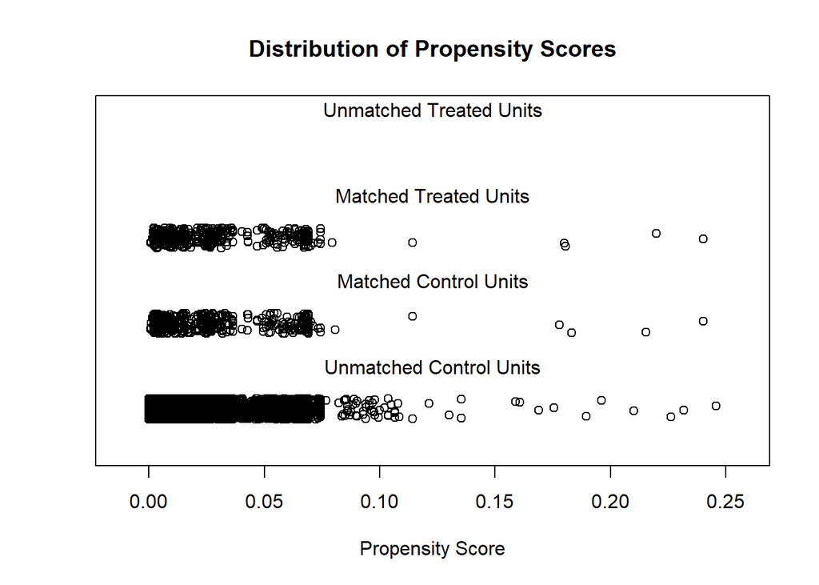

```r
# sieht besser aus als vorher

# Jitter plot
plot(nnm, type = "jitter", interactive = FALSE)
```

```r
# with cobalt package:
# distributional density/histogram
bal.plot(nnm, var.name = "age", which = "both", grid = T)
```

```r
bal.plot(nnm, var.name = "relationship_length", which = "both", grid = T)
```

```r
bal.plot(nnm, var.name = "relationship_status", which = "both", grid = T)
```

```r
bal.plot(nnm, var.name = "language", which = "both", grid = T)
```

```r
bal.plot(nnm, var.name = "country", which = "both", grid = T) # recht unübersichtlich
```

```r
love.plot(bal.tab(nnm, m.threshold = 0.1),
          stat = "mean.diffs",
          grid = T,
          stars = "raw",
          abs = F)
```

```r
# mega unübersichtlich wegen Country Variable

# remove country variable for love plot
nnm_without_country = nnm
nnm_without_country$X[c("country")] <- NULL

love.plot(bal.tab(nnm_without_country, m.threshold = 0.1),
          stat = "mean.diffs",
          grid = T,
          stars = "raw",
          abs = F)
```

## **hilfreiche Funktionen**

```r
# check matched pairs
# matchedobject$match.matrix

# nnm --> order in which treated individuals is picked "largest", "mallest" or "random" (m.order = "largest")
# nnm --> caliper (caliper = number) 8caliper = number of standard deviations of difference which can be tolerated between PS of the matched pair (default = 0 -- no caliper)
```

## get same results every time?

here is an element of randomness when using matchit() and ties are present in the data. A tie occurs when two units of the same treatment group have the same propensity score. In versions of MatchIt prior to 4.0.0, a member of the tie is randomly sampled, so you may get different results each time.

In MatchIt 4.0.0, which is now on CRAN, you should get the same results each time unless you reshuffle the dataset or select a random matching order. Ties are resolved by choosing units based on the order of the data. This adds a level of arbitrariness but ensures results are replicable when using the exact same dataset